# ESM 202 Assignment 1

Keene Morrow

1/21/2020

| Chesapeake Bay Contributing Rivers USGS Site ID | Chesapeake Bay Contributing Rivers River | Chesapeake Bay Contributing Rivers River Abbreviation | Chesapeake Bay Contributing Rivers Location | Chesapeake Bay Contributing Rivers State | Chesapeake Bay Contributing Rivers Mean Flow (m3/s) |
| --- | --- | --- | --- | --- | --- |
| 1578310 | Susquehanna River | SUS | Conowingo | MD | 1145 |
| 1646580 | Potomac River | POT | Chain Br | DC | 347 |
| 2035000 | James River | NA | Cartersville | VA | 200 |
| 1668000 | Rappahannock River | NA | Fredericksburg | VA | 49 |
| 2041650 | Appomattox River | NA | Matoaca | VA | 34 |
| 1673000 | Pamunkey River | NA | Hanover | VA | 28 |
| 1674500 | Mattaponi River | NA | Beulahville | VA | 15 |
| 1594440 | Patuxent River | NA | Bowie | MD | 11 |
| 1491000 | Choptank River | CHO | Greensboro | MD | 4 |

### 1. Mass Balance

#### a) Calculate the percent contribution of each river to the total water flux into the Chesapeake Bay.

```r
river_contrib <- rivers %>%
  mutate(pct_contrib = round((mean_flow_m3_s / ch_tot_inflow)*100, digits = 2)) %>%
  select(river, pct_contrib) %>%
  rename("Percent Contribution" = pct_contrib,
         River = river)
```

| Table 1. Percent Contribution to Chesapeake Bay Flux by River River | Table 1. Percent Contribution to Chesapeake Bay Flux by River Percent Contribution |
| --- | --- |
| Susquehanna River | 62.47 |
| Potomac River | 18.93 |
| James River | 10.91 |
| Rappahannock River | 2.67 |
| Appomattox River | 1.85 |
| Pamunkey River | 1.53 |
| Mattaponi River | 0.82 |
| Patuxent River | 0.60 |
| Choptank River | 0.22 |

#### b) Considering the rivers as the total inflow, what is the approximate turnover time for water in the Chesapeake Bay? Assume that tidal exchange has no net effect on the total volume of the Chesapeake Bay.

```r
# Chesapeake Bay turnover in seconds
ch_turnover <- ch_tot_V_m / ch_tot_inflow

# Chesapeake Bay turnover in days
ch_turn_days <- ch_turnover / (60 ^ 2 * 24)

# Chesapeake Bay turnover in years
ch_turn_yr <- ch_turn_days / 365.25
```

The turnover time of the Chesapeake Bay is 429.37 days or 1.18 years.

#### c) What is the mean concentration (in μg/L) of total nitrogen (TN) and total phosphorus (TP) entering the Chesapeake Bay from each river (only SUS, POT and CHO) in the 1st quarter of 2010?

```r
# Total Phosphorus kg/day, 2010, Quarter 1, in order, SUS, POT, CHO
tp_2010_q1_kg_d <- c(1.6 * 7200, 1.4 * 4700, 1.5 * 40)

# Total Nitrogen kg/day, 2010, Quarter 1, in order, SUS, POT, CHO
tn_2010_q1_kg_d <- c(1.5 * 160000, 1.5 * 64000, 1.75 * 600)

rivers_ug_L <- rivers %>%
  # only the rivers of interest
  filter(river_abb %in% c("SUS", "POT", "CHO")) %>%
  # add TP and TN data from above
  cbind(tp_2010_q1_kg_d,
        tn_2010_q1_kg_d) %>%
  # Conversions
  mutate(mean_flow_L_s = mean_flow_m3_s * 1000,
         tp_2010_q1_ug_d = tp_2010_q1_kg_d * 10 ^ 9,
         tn_2010_q1_ug_d = tn_2010_q1_kg_d * 10 ^ 9) %>%
  mutate(tp_2010_q1_ug_s = tp_2010_q1_ug_d / 86400,
         tn_2010_q1_ug_s = tn_2010_q1_ug_d / 86400) %>%
  # Calculate Mean Concentration of TP and TN in each river
  mutate(mean_conc_tp_2010_q1_ug_L = tp_2010_q1_ug_s / mean_flow_L_s,
         mean_conc_tn_2010_q1_ug_L = tn_2010_q1_ug_s / mean_flow_L_s)

# Prep df for table
mean_conc_2010 <- rivers_ug_L %>%
  select(river, mean_conc_tp_2010_q1_ug_L, mean_conc_tn_2010_q1_ug_L) %>%
  mutate(mean_conc_tp_2010_q1_ug_L = round(mean_conc_tp_2010_q1_ug_L, digits = 2),
         mean_conc_tn_2010_q1_ug_L= round(mean_conc_tn_2010_q1_ug_L, digits = 2)) %>%
  rename("Total Phosphorus" = mean_conc_tp_2010_q1_ug_L,
         "Total Nitrogen" = mean_conc_tn_2010_q1_ug_L,
         River = river)
```

| Table 2. Mean Concentrations (µg/L) entering the Chesapeake Bay by River Quarter 1, 2010 River | Table 2. Mean Concentrations (µg/L) entering the Chesapeake Bay by River Quarter 1, 2010 Total Phosphorus | Table 2. Mean Concentrations (µg/L) entering the Chesapeake Bay by River Quarter 1, 2010 Total Nitrogen |
| --- | --- | --- |
| Susquehanna River | 116.45 | 2426.01 |
| Potomac River | 219.47 | 3202.05 |
| Choptank River | 173.61 | 3038.19 |

#### d) Express the concentrations of TN and TP also in terms of moles/L of N and P.

```r
N_atomic <- 14.00 # g / mol
P_atomic <- 30.97 # g / mol

N_ug_mol <- N_atomic * 10 ^ 6 # ug / mol
P_ug_mol <- P_atomic * 10 ^ 6 # ug / mol

mean_conc_2010_mol_L <- rivers_ug_L %>%
  # Convert ug/L to mol/L
  mutate(mean_conc_tp_2010_q1_mol_L = mean_conc_tp_2010_q1_ug_L / P_ug_mol,
         mean_conc_tn_2010_q1_mol_L = mean_conc_tn_2010_q1_ug_L / N_ug_mol) %>%
  # Prep for table
  select(river, mean_conc_tp_2010_q1_mol_L, mean_conc_tn_2010_q1_mol_L) %>%
  mutate(mean_conc_tp_2010_q1_mol_L = formatC(mean_conc_tp_2010_q1_mol_L, format = "e", digits = 2),
         mean_conc_tn_2010_q1_mol_L= formatC(mean_conc_tn_2010_q1_mol_L, format= "e", digits = 2)) %>%
  rename("Total Phosphorus" = mean_conc_tp_2010_q1_mol_L,
         "Total Nitrogen" = mean_conc_tn_2010_q1_mol_L,
         River = river)
```

| Table 3. Mean Concentrations (mol/L) entering the Chesapeake Bay by River Quarter 1, 2010 River | Table 3. Mean Concentrations (mol/L) entering the Chesapeake Bay by River Quarter 1, 2010 Total Phosphorus | Table 3. Mean Concentrations (mol/L) entering the Chesapeake Bay by River Quarter 1, 2010 Total Nitrogen |
| --- | --- | --- |
| Susquehanna River | 3.76e-06 | 1.73e-04 |
| Potomac River | 7.09e-06 | 2.29e-04 |
| Choptank River | 5.61e-06 | 2.17e-04 |

#### e) How many kg of TN and TP are being discharged into the Chesapeake Bay from each river (only SUS, POT and CHO) in the 1st quarter of 2010?

```r
t_q1_d <- 31 + # January
  28 + # February
  31 # March

rivers_kg_q1 <- rivers %>%
  # only the rivers of interest
  filter(river_abb %in% c("SUS", "POT", "CHO")) %>%
  # add TP and TN data from above
  cbind(tp_2010_q1_kg_d,
        tn_2010_q1_kg_d) %>%
  mutate(tp_2010_q1_kg_qtr = tp_2010_q1_kg_d * t_q1_d,
         tn_2010_q1_kg_qtr = tn_2010_q1_kg_d * t_q1_d) %>%
  select(river, tp_2010_q1_kg_qtr, tn_2010_q1_kg_qtr) %>%
  rename("Total Phosphorus" = tp_2010_q1_kg_qtr,
         "Total Nitrogen" = tn_2010_q1_kg_qtr,
         River = river)
```

| Table 4. Total Contribution (kg) entering the Chesapeake Bay by River Quarter 1, 2010 River | Table 4. Total Contribution (kg) entering the Chesapeake Bay by River Quarter 1, 2010 Total Phosphorus | Table 4. Total Contribution (kg) entering the Chesapeake Bay by River Quarter 1, 2010 Total Nitrogen |
| --- | --- | --- |
| Susquehanna River | 1036800 | 21600000 |
| Potomac River | 592200 | 8640000 |
| Choptank River | 5400 | 94500 |

#### f) Approximately what fraction of the total mass of N and P is coming in as dissolved N (DN) or dissolved P (DP) in the 1st quarter of 2010?

```r
# Dissolved Phosphorus kg/day, 2010, Quarter 1, in order, SUS, POT, CHO
dp_2010_q1_kg_d <- c(1.2 * 1600, 0.7 * 1100, 1.3 * 14)

# Dissolved Nitrogen kg/day, 2010, Quarter 1, in order, SUS, POT, CHO
dn_2010_q1_kg_d <- c(1.4 * 140000, 1.5 * 48000, 1.7 * 540)


rivers_dis_tot <- rivers %>%
  # only the rivers of interest
  filter(river_abb %in% c("SUS", "POT", "CHO")) %>%
  # add TP, TN, DP, DN data from above
  cbind(dp_2010_q1_kg_d,
        tp_2010_q1_kg_d) %>%
  mutate(dis_tot_P_2010_q1_kg_d = round((dp_2010_q1_kg_d /tp_2010_q1_kg_d), digits = 2)) %>%
  cbind(dn_2010_q1_kg_d,
        tn_2010_q1_kg_d) %>%
  mutate(dis_tot_N_2010_q1_kg_d = round((dn_2010_q1_kg_d /tn_2010_q1_kg_d), digits = 2)) %>%
  select(river, dis_tot_P_2010_q1_kg_d, dis_tot_N_2010_q1_kg_d) %>%
  rename(River = river,
         "Nitrogen" = dis_tot_N_2010_q1_kg_d,
         "Phosphorus" = dis_tot_P_2010_q1_kg_d)
```

| Table 5. Contribution of Dissolved Mass to Total Mass entering the Chesapeake Bay by River Quarter 1, 2010 River | Table 5. Contribution of Dissolved Mass to Total Mass entering the Chesapeake Bay by River Quarter 1, 2010 Phosphorus | Table 5. Contribution of Dissolved Mass to Total Mass entering the Chesapeake Bay by River Quarter 1, 2010 Nitrogen |
| --- | --- | --- |
| Susquehanna River | 0.17 | 0.82 |
| Potomac River | 0.12 | 0.75 |
| Choptank River | 0.30 | 0.87 |

#### g) Calculate the total mass/day of suspended sediments being added to the Chesapeake Bay during the 1st quarter of 2010 by each river.

```r
susp_solids <- c(2.2 * 4300000, 1.75 * 4100000, 1.8 * 7100)

rivers_solids <- rivers %>%
  # only the rivers of interest
  filter(river_abb %in% c("SUS", "POT", "CHO")) %>%
  # add TP, TN, DP, DN data from above
  cbind(susp_solids) %>%
  select(river, susp_solids) %>%
  rename(River = river,
         "Suspended Solids" = susp_solids)
```

| Table 6. Contribution of Suspended Solids (kg/day) to the Chesapeake Bay by River Quarter 1, 2010 River | Table 6. Contribution of Suspended Solids (kg/day) to the Chesapeake Bay by River Quarter 1, 2010 Suspended Solids |
| --- | --- |
| Susquehanna River | 9460000 |
| Potomac River | 7175000 |
| Choptank River | 12780 |

### 2. Water quality (consider only the SUS, POT and CHO or as indicated)

#### a) Given the molar ratio of 100:16:1 [C:N:P], which nutrient would be limiting in each river during the 1st quarter of 2010?

```r
wq_limitation <- rivers_ug_L %>%
  # Convert ug/L to mol/L
  mutate(mean_conc_tp_2010_q1_mol_L = mean_conc_tp_2010_q1_ug_L / P_ug_mol,
         mean_conc_tn_2010_q1_mol_L = mean_conc_tn_2010_q1_ug_L / N_ug_mol) %>%
  mutate(ratio_N_P = mean_conc_tn_2010_q1_mol_L / mean_conc_tp_2010_q1_mol_L) %>%
  mutate(limited = ifelse(ratio_N_P < 10, "Nitrogen", ifelse(ratio_N_P >30, "Phosphorus", "Not Limited"))) %>%
  select(river, limited) %>%
  rename(River = river,
         "Limited by" = limited)
```

| Table 7. Limiting Nutrients Quarter 1, 2010 River | Table 7. Limiting Nutrients Quarter 1, 2010 Limited by |
| --- | --- |
| Susquehanna River | Phosphorus |
| Potomac River | Phosphorus |
| Choptank River | Phosphorus |

```r
DO_mg_L <- 4.5 # mg/L
O_atomic <- 16 # g / mol

DO_mol_L <- (DO_mg_L / 1000) / 16

dn_cho_mol_L <- (rivers_ug_L$mean_conc_tn_2010_q1_ug_L[3] * rivers_dis_tot$Nitrogen[3]) / N_ug_mol

dn_cho_mg <- rivers_ug_L$mean_conc_tn_2010_q1_ug_L[3] / 1000

ratio_dn_DO_cho <- dn_cho_mol_L / DO_mol_L

ratio_df_el <- c("C", "N", "P", "H", "O")
ratio_df_num <- c(100, 16, 1, 200, 100)
ratio_cho_DO <- c("", "", "", "", DO_mol_L)
ratio_cho_DN <- c("", dn_cho_mol_L, "", "", "")

ratio <- as.data.frame(ratio_df_el) %>%
  cbind(ratio_df_num) %>%
  mutate(DO_ratio = ratio_df_num / 100,
         DN_ratio = ratio_df_num / 16) %>%
  mutate(DO_level = DO_ratio * DO_mol_L,
         DN_level = DN_ratio * dn_cho_mol_L) %>%
  rename(element = ratio_df_el,
         std_ratio = ratio_df_num)
```

#### d) Given the concentrations of TN and TP, how would you classify the eutrophication potential of each of the three rivers in terms in the Chesapeake Bay in 1980 and 2010?

```r
# Total Phosphorus kg/day, 1980, Quarter 1, in order, SUS, POT, CHO
tp_1980_q1_kg_d <- c(2.0 * 7200, 2.0 * 4700, 1.3 * 40)

# Total Nitrogen kg/day, 1980, Quarter 1, in order, SUS, POT, CHO
tn_1980_q1_kg_d <- c(1.6 * 160000, 1.75 * 64000, 1.5 * 600)


eutrophication <- rivers %>%
  # only the rivers of interest
  filter(river_abb %in% c("SUS", "POT", "CHO")) %>%
  # add TP and TN data from above
  cbind(tp_1980_q1_kg_d,
        tn_1980_q1_kg_d,
        tp_2010_q1_kg_d,
        tn_2010_q1_kg_d) %>%
  # Conversions
  mutate(mean_flow_L_s = mean_flow_m3_s * 1000,
         tp_1980_q1_ug_d = tp_1980_q1_kg_d * 10 ^ 9,
         tn_1980_q1_ug_d = tn_1980_q1_kg_d * 10 ^ 9,
         tp_2010_q1_ug_d = tp_2010_q1_kg_d * 10 ^ 9,
         tn_2010_q1_ug_d = tn_2010_q1_kg_d * 10 ^ 9) %>%
  mutate(tp_1980_q1_ug_s = tp_1980_q1_ug_d / 86400,
         tn_1980_q1_ug_s = tn_1980_q1_ug_d / 86400,
         tp_2010_q1_ug_s = tp_2010_q1_ug_d / 86400,
         tn_2010_q1_ug_s = tn_2010_q1_ug_d / 86400) %>%
  # Calculate Mean Concentration of TP and TN in each river
  mutate(mean_conc_tp_1980_q1_ug_L = tp_1980_q1_ug_s / mean_flow_L_s,
         mean_conc_tn_1980_q1_ug_L = tn_1980_q1_ug_s / mean_flow_L_s,
         mean_conc_tp_2010_q1_ug_L = tp_2010_q1_ug_s / mean_flow_L_s,
         mean_conc_tn_2010_q1_ug_L = tn_2010_q1_ug_s / mean_flow_L_s) %>%
  mutate(ratio_N_P_1980 = mean_conc_tn_1980_q1_ug_L / mean_conc_tp_1980_q1_ug_L,
         ratio_N_P_2010 = mean_conc_tn_2010_q1_ug_L / mean_conc_tp_2010_q1_ug_L,
         eu_potential_1980 = ifelse(mean_conc_tp_1980_q1_ug_L > 15, ifelse(mean_conc_tp_1980_q1_ug_L > 100, "Potentially Hypereutrophic", "Likely Eutrophic"), "Unlikely Eutrophic" ),
         eu_potential_2010 = ifelse(mean_conc_tp_2010_q1_ug_L > 15, ifelse(mean_conc_tp_2010_q1_ug_L > 100, "Potentially Hypereutrophic", "Likely Eutrophic"), "Unlikely Eutrophic" ))
```

In both 1980 and 2010 all three rivers had sufficient total nitrogen and total phosphorus levels to have a high eutrophication potential, to the extent that they were all potentially hypertrophic in both years.

#### e) What other water quality parameter(s) are important to determine the health of aquatic organisms (e.g. fish) in these three tributaries? Briefly discuss at least 5.

- The pH of water controls what forms of elements are present and therefore are available to organisms or implicated in natural processes. Low pH or acidic conditions speeds weathering and may influence the hardness of water. High pH or alkaline conditions may increase metal precipitation and NH<sub>3</sub>.
- Cations are ions with positive charges. They have a variety of valencies, with sodium and potassium representing common monovalent cations and magnesium and calcium representing divalent cations. Hard water has high concentrations of calcium and magnesium, which may result in deposits forming on fixtures and reduce the efficacy of detergents. Soft water has low concentrations of ions, especially calcium and magnesium, and may be corrosive. The public health concern of soft water can be seen in the Flint Water Crisis, where soft water corroded pipes, exposing residents to lead. Anions, negatively charged ions, are present in equal proportion to cations.
- Tubidity is more than just suspended solids. This measures the ability of light to penetrate the water quality. Turbidity influences the ability of organisms to survive in a water body, with different organisms adapted for different levels of turbidity. Elevated turbidity may come from runoff, particularly in places that previously had groundcover and lost it, perhaps through a fire. Reduced turbidity may come from the introduction of an invasive species, such as the zebra mussel in the Hudson River, or from a change in flow velocity.
- Abnormally elevated temperature in water bodies is often caused by human activities such as the discharge of water from power plants. High water temperatures are associated with reduced dissolved oxygen levels, which in turn negatively affect organisms living in the water body. A resulting fish kill, or mass die off of fish, can cause a cascade of impacts due to the disruption of the food web and resulting increase in decomposable matter.
- Salinity is typically measured as a function of water density, with denser water having a more dissolved salts. Organisms typically prefer a certain range of salinities and disruptions to salinity disrupt the osmotic processes that maintain their cells. Elevated salinity also reduces the suitability of water for human consumption and increases the cost of water treatment. Saline conditions may occur naturally or be influenced by runoff.

#### f) Given the loadings of N and P, qualitatively discuss the likely redox conditions in the Chesapeake Bay sediments. What are the implications (briefly)?

Elevated levels of nitrogen and phosphorus reduce dissolved oxygen levels, pushing conditions towards a more reducing state. The redox state of a water body influences the availability and toxicity of elements. A reducing state is associated with the presence of additional free metals, which may negatively impact human health and the health of organisms in water bodies.

#### g) For the data sets provided (1980 to 2010), discuss the relative improvement/degradation of each river in the Chesapeake Bay.

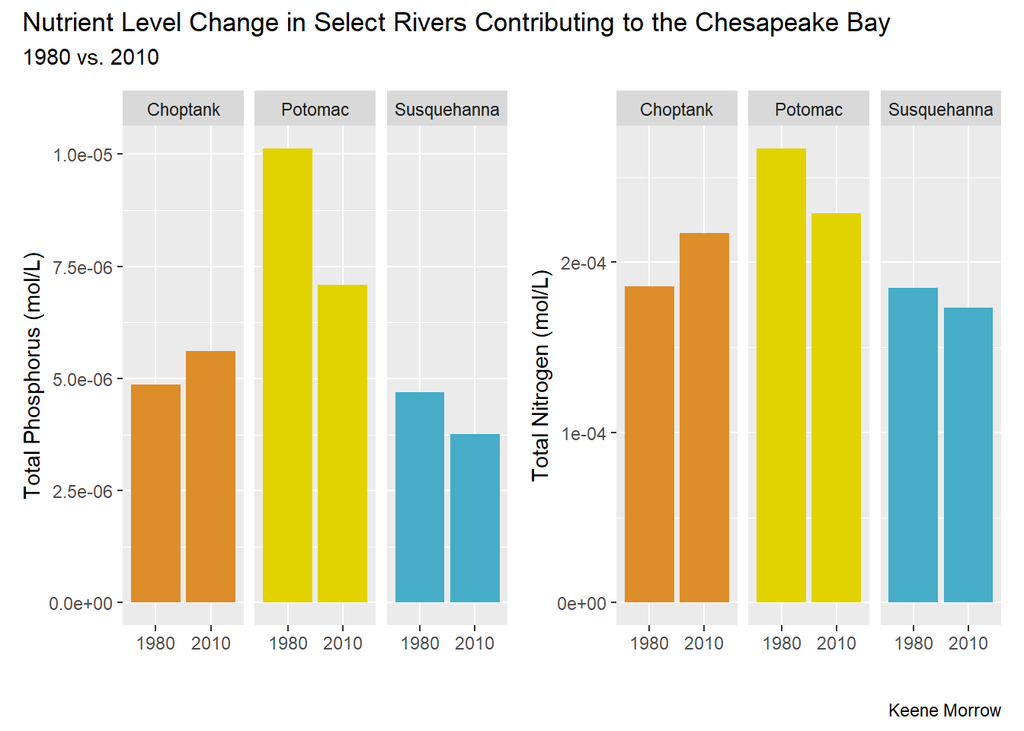

Between 1980 and 2010 the Potomac and Susquehanna Rivers saw reductions in both total phosphorus and total nitrogen, with the greatest reduction being in total phosphorus in the Potomac. By contrast, both total phosphorus and total nitrogen increased in the Choptank River in the same time period. This difference is liekly due to the Choptank’s contributing area being exclusively agricultural land versus the Potomac being urban in addition to agricultural and the Susquehanna being forested and rural in addition to agricultural. It is expected that the princinpal source of excess nitrogen and phosphorus in the rivers is agricultural runoff.